# Risk Factor Analysis

## Outcome Variable

**Outcome Variable:** sstunted

## Predictor Variables

**Intervention Variable:** birthwt

**Adjustment Set:**

- arm
- sex
- W_mage
- meducyrs
- feducyrs
- vagbrth
- single
- brthmon
- W_parity
- delta_W_mage
- delta_meducyrs
- delta_feducyrs
- delta_vagbrth
- delta_single
- delta_brthmon
- delta_W_parity

## Stratifying Variables

The analysis was stratified on these variable(s):

- agecat
- studyid
- country

## Data Summary

| agecat | studyid | country | birthwt | sstunted | n_cell | n |
| --- | --- | --- | --- | --- | --- | --- |
| Birth | ki0047075b-MAL-ED | BANGLADESH | Normal or high birthweight | 0 | 176 | 231 |
| Birth | ki0047075b-MAL-ED | BANGLADESH | Normal or high birthweight | 1 | 1 | 231 |
| Birth | ki0047075b-MAL-ED | BANGLADESH | Low birthweight | 0 | 46 | 231 |
| Birth | ki0047075b-MAL-ED | BANGLADESH | Low birthweight | 1 | 8 | 231 |
| Birth | ki0047075b-MAL-ED | BRAZIL | Normal or high birthweight | 0 | 59 | 65 |
| Birth | ki0047075b-MAL-ED | BRAZIL | Normal or high birthweight | 1 | 2 | 65 |
| Birth | ki0047075b-MAL-ED | BRAZIL | Low birthweight | 0 | 3 | 65 |
| Birth | ki0047075b-MAL-ED | BRAZIL | Low birthweight | 1 | 1 | 65 |
| Birth | ki0047075b-MAL-ED | INDIA | Normal or high birthweight | 0 | 38 | 47 |
| Birth | ki0047075b-MAL-ED | INDIA | Normal or high birthweight | 1 | 1 | 47 |
| Birth | ki0047075b-MAL-ED | INDIA | Low birthweight | 0 | 7 | 47 |
| Birth | ki0047075b-MAL-ED | INDIA | Low birthweight | 1 | 1 | 47 |
| Birth | ki0047075b-MAL-ED | NEPAL | Normal or high birthweight | 0 | 24 | 27 |
| Birth | ki0047075b-MAL-ED | NEPAL | Normal or high birthweight | 1 | 0 | 27 |
| Birth | ki0047075b-MAL-ED | NEPAL | Low birthweight | 0 | 2 | 27 |
| Birth | ki0047075b-MAL-ED | NEPAL | Low birthweight | 1 | 1 | 27 |
| Birth | ki0047075b-MAL-ED | PERU | Normal or high birthweight | 0 | 220 | 233 |
| Birth | ki0047075b-MAL-ED | PERU | Normal or high birthweight | 1 | 1 | 233 |
| Birth | ki0047075b-MAL-ED | PERU | Low birthweight | 0 | 9 | 233 |
| Birth | ki0047075b-MAL-ED | PERU | Low birthweight | 1 | 3 | 233 |
| Birth | ki0047075b-MAL-ED | SOUTH AFRICA | Normal or high birthweight | 0 | 115 | 123 |
| Birth | ki0047075b-MAL-ED | SOUTH AFRICA | Normal or high birthweight | 1 | 0 | 123 |
| Birth | ki0047075b-MAL-ED | SOUTH AFRICA | Low birthweight | 0 | 6 | 123 |
| Birth | ki0047075b-MAL-ED | SOUTH AFRICA | Low birthweight | 1 | 2 | 123 |
| Birth | ki0047075b-MAL-ED | TANZANIA, UNITED REPUBLIC OF | Normal or high birthweight | 0 | 113 | 125 |
| Birth | ki0047075b-MAL-ED | TANZANIA, UNITED REPUBLIC OF | Normal or high birthweight | 1 | 5 | 125 |
| Birth | ki0047075b-MAL-ED | TANZANIA, UNITED REPUBLIC OF | Low birthweight | 0 | 2 | 125 |
| Birth | ki0047075b-MAL-ED | TANZANIA, UNITED REPUBLIC OF | Low birthweight | 1 | 5 | 125 |
| Birth | ki1000108-CMC-V-BCS-2002 | INDIA | Normal or high birthweight | 0 | 78 | 92 |
| Birth | ki1000108-CMC-V-BCS-2002 | INDIA | Normal or high birthweight | 1 | 3 | 92 |

[output cut: 282 more lines]

The following strata were considered:

- agecat: 24 months, studyid: ki0047075b-MAL-ED, country: BANGLADESH
- agecat: 24 months, studyid: ki0047075b-MAL-ED, country: BRAZIL
- agecat: 24 months, studyid: ki0047075b-MAL-ED, country: INDIA
- agecat: 24 months, studyid: ki0047075b-MAL-ED, country: NEPAL
- agecat: 24 months, studyid: ki0047075b-MAL-ED, country: PERU
- agecat: 24 months, studyid: ki0047075b-MAL-ED, country: SOUTH AFRICA
- agecat: 24 months, studyid: ki0047075b-MAL-ED, country: TANZANIA, UNITED REPUBLIC OF
- agecat: 24 months, studyid: ki1000108-CMC-V-BCS-2002, country: INDIA
- agecat: 24 months, studyid: ki1000108-IRC, country: INDIA
- agecat: 24 months, studyid: ki1000109-EE, country: PAKISTAN
- agecat: 24 months, studyid: ki1017093-NIH-Birth, country: BANGLADESH
- agecat: 24 months, studyid: ki1017093b-PROVIDE, country: BANGLADESH
- agecat: 24 months, studyid: ki1017093c-NIH-Crypto, country: BANGLADESH
- agecat: 24 months, studyid: ki1066203-TanzaniaChild2, country: TANZANIA, UNITED REPUBLIC OF
- agecat: 24 months, studyid: ki1101329-Keneba, country: GAMBIA
- agecat: 24 months, studyid: ki1113344-GMS-Nepal, country: NEPAL
- agecat: 24 months, studyid: ki1114097-CMIN, country: BANGLADESH
- agecat: 24 months, studyid: ki1114097-CONTENT, country: PERU
- agecat: 24 months, studyid: ki1119695-PROBIT, country: BELARUS
- agecat: 24 months, studyid: ki1126311-ZVITAMBO, country: ZIMBABWE
- agecat: 24 months, studyid: ki1135781-COHORTS, country: GUATEMALA
- agecat: 24 months, studyid: ki1135781-COHORTS, country: INDIA
- agecat: 24 months, studyid: ki1135781-COHORTS, country: PHILIPPINES
- agecat: 24 months, studyid: kiGH5241-JiVitA-3, country: BANGLADESH
- agecat: 24 months, studyid: kiGH5241-JiVitA-4, country: BANGLADESH
- agecat: 6 months, studyid: ki0047075b-MAL-ED, country: BANGLADESH
- agecat: 6 months, studyid: ki0047075b-MAL-ED, country: BRAZIL
- agecat: 6 months, studyid: ki0047075b-MAL-ED, country: INDIA
- agecat: 6 months, studyid: ki0047075b-MAL-ED, country: NEPAL
- agecat: 6 months, studyid: ki0047075b-MAL-ED, country: PERU
- agecat: 6 months, studyid: ki0047075b-MAL-ED, country: SOUTH AFRICA
- agecat: 6 months, studyid: ki0047075b-MAL-ED, country: TANZANIA, UNITED REPUBLIC OF
- agecat: 6 months, studyid: ki1000108-CMC-V-BCS-2002, country: INDIA
- agecat: 6 months, studyid: ki1000108-IRC, country: INDIA
- agecat: 6 months, studyid: ki1000109-EE, country: PAKISTAN
- agecat: 6 months, studyid: ki1000109-ResPak, country: PAKISTAN
- agecat: 6 months, studyid: ki1000304b-SAS-CompFeed, country: INDIA
- agecat: 6 months, studyid: ki1017093-NIH-Birth, country: BANGLADESH
- agecat: 6 months, studyid: ki1017093b-PROVIDE, country: BANGLADESH
- agecat: 6 months, studyid: ki1017093c-NIH-Crypto, country: BANGLADESH
- agecat: 6 months, studyid: ki1066203-TanzaniaChild2, country: TANZANIA, UNITED REPUBLIC OF
- agecat: 6 months, studyid: ki1101329-Keneba, country: GAMBIA
- agecat: 6 months, studyid: ki1113344-GMS-Nepal, country: NEPAL
- agecat: 6 months, studyid: ki1114097-CMIN, country: BANGLADESH
- agecat: 6 months, studyid: ki1114097-CONTENT, country: PERU
- agecat: 6 months, studyid: ki1119695-PROBIT, country: BELARUS
- agecat: 6 months, studyid: ki1126311-ZVITAMBO, country: ZIMBABWE
- agecat: 6 months, studyid: ki1135781-COHORTS, country: GUATEMALA
- agecat: 6 months, studyid: ki1135781-COHORTS, country: INDIA
- agecat: 6 months, studyid: ki1135781-COHORTS, country: PHILIPPINES
- agecat: 6 months, studyid: kiGH5241-JiVitA-3, country: BANGLADESH
- agecat: 6 months, studyid: kiGH5241-JiVitA-4, country: BANGLADESH
- agecat: Birth, studyid: ki0047075b-MAL-ED, country: BANGLADESH
- agecat: Birth, studyid: ki0047075b-MAL-ED, country: BRAZIL
- agecat: Birth, studyid: ki0047075b-MAL-ED, country: INDIA
- agecat: Birth, studyid: ki0047075b-MAL-ED, country: NEPAL
- agecat: Birth, studyid: ki0047075b-MAL-ED, country: PERU
- agecat: Birth, studyid: ki0047075b-MAL-ED, country: SOUTH AFRICA
- agecat: Birth, studyid: ki0047075b-MAL-ED, country: TANZANIA, UNITED REPUBLIC OF
- agecat: Birth, studyid: ki1000108-CMC-V-BCS-2002, country: INDIA
- agecat: Birth, studyid: ki1000108-IRC, country: INDIA
- agecat: Birth, studyid: ki1000109-EE, country: PAKISTAN
- agecat: Birth, studyid: ki1000109-ResPak, country: PAKISTAN
- agecat: Birth, studyid: ki1000304b-SAS-CompFeed, country: INDIA
- agecat: Birth, studyid: ki1017093-NIH-Birth, country: BANGLADESH
- agecat: Birth, studyid: ki1017093b-PROVIDE, country: BANGLADESH
- agecat: Birth, studyid: ki1017093c-NIH-Crypto, country: BANGLADESH
- agecat: Birth, studyid: ki1101329-Keneba, country: GAMBIA
- agecat: Birth, studyid: ki1113344-GMS-Nepal, country: NEPAL
- agecat: Birth, studyid: ki1114097-CMIN, country: BANGLADESH
- agecat: Birth, studyid: ki1114097-CONTENT, country: PERU
- agecat: Birth, studyid: ki1119695-PROBIT, country: BELARUS
- agecat: Birth, studyid: ki1126311-ZVITAMBO, country: ZIMBABWE
- agecat: Birth, studyid: ki1135781-COHORTS, country: GUATEMALA
- agecat: Birth, studyid: ki1135781-COHORTS, country: INDIA
- agecat: Birth, studyid: ki1135781-COHORTS, country: PHILIPPINES
- agecat: Birth, studyid: kiGH5241-JiVitA-3, country: BANGLADESH
- agecat: Birth, studyid: kiGH5241-JiVitA-4, country: BANGLADESH

### Dropped Strata

Some strata were dropped due to rare outcomes:

- agecat: Birth, studyid: ki0047075b-MAL-ED, country: BANGLADESH
- agecat: Birth, studyid: ki0047075b-MAL-ED, country: BRAZIL
- agecat: Birth, studyid: ki0047075b-MAL-ED, country: INDIA
- agecat: Birth, studyid: ki0047075b-MAL-ED, country: NEPAL
- agecat: Birth, studyid: ki0047075b-MAL-ED, country: PERU
- agecat: Birth, studyid: ki0047075b-MAL-ED, country: SOUTH AFRICA
- agecat: Birth, studyid: ki0047075b-MAL-ED, country: TANZANIA, UNITED REPUBLIC OF
- agecat: Birth, studyid: ki1000108-CMC-V-BCS-2002, country: INDIA
- agecat: Birth, studyid: ki1000109-ResPak, country: PAKISTAN
- agecat: Birth, studyid: ki1017093-NIH-Birth, country: BANGLADESH
- agecat: Birth, studyid: ki1017093b-PROVIDE, country: BANGLADESH
- agecat: Birth, studyid: ki1017093c-NIH-Crypto, country: BANGLADESH
- agecat: Birth, studyid: ki1113344-GMS-Nepal, country: NEPAL
- agecat: Birth, studyid: ki1114097-CMIN, country: BANGLADESH
- agecat: Birth, studyid: ki1114097-CONTENT, country: PERU
- agecat: Birth, studyid: ki1119695-PROBIT, country: BELARUS
- agecat: Birth, studyid: ki1135781-COHORTS, country: GUATEMALA
- agecat: 6 months, studyid: ki0047075b-MAL-ED, country: BANGLADESH
- agecat: 6 months, studyid: ki0047075b-MAL-ED, country: BRAZIL
- agecat: 6 months, studyid: ki0047075b-MAL-ED, country: INDIA
- agecat: 6 months, studyid: ki0047075b-MAL-ED, country: NEPAL
- agecat: 6 months, studyid: ki0047075b-MAL-ED, country: PERU
- agecat: 6 months, studyid: ki0047075b-MAL-ED, country: SOUTH AFRICA
- agecat: 6 months, studyid: ki0047075b-MAL-ED, country: TANZANIA, UNITED REPUBLIC OF
- agecat: 6 months, studyid: ki1000109-ResPak, country: PAKISTAN
- agecat: 6 months, studyid: ki1017093b-PROVIDE, country: BANGLADESH
- agecat: 6 months, studyid: ki1066203-TanzaniaChild2, country: TANZANIA, UNITED REPUBLIC OF
- agecat: 6 months, studyid: ki1114097-CMIN, country: BANGLADESH
- agecat: 6 months, studyid: ki1114097-CONTENT, country: PERU
- agecat: 6 months, studyid: ki1119695-PROBIT, country: BELARUS
- agecat: 24 months, studyid: ki0047075b-MAL-ED, country: BRAZIL
- agecat: 24 months, studyid: ki0047075b-MAL-ED, country: NEPAL
- agecat: 24 months, studyid: ki0047075b-MAL-ED, country: PERU
- agecat: 24 months, studyid: ki0047075b-MAL-ED, country: SOUTH AFRICA
- agecat: 24 months, studyid: ki0047075b-MAL-ED, country: TANZANIA, UNITED REPUBLIC OF
- agecat: 24 months, studyid: ki1066203-TanzaniaChild2, country: TANZANIA, UNITED REPUBLIC OF
- agecat: 24 months, studyid: ki1114097-CMIN, country: BANGLADESH
- agecat: 24 months, studyid: ki1114097-CONTENT, country: PERU
- agecat: 24 months, studyid: ki1119695-PROBIT, country: BELARUS

## Methods Detail

We’re interested in the causal parameters $E[Y_a]$ for all values of $a \in \mathcal{A}$. These parameters represent the mean outcome if, possibly contrary to fact, we intervened to set all units to have $A=a$. Under the randomization and positivity assumptions, these are identified by the statistical parameters $\psi_a=E_W[E_{Y|A,W}(Y|A=a,W)]$. In addition, we’re interested in the mean of $Y$, $E[Y]$ under no intervention (the observed mean). We will estimate these parameters by using SuperLearner to fit the relevant likelihood factors – $E_{Y|A,W}(Y|A=a,W)$ and $p(A=a|W)$, and then updating our likelihood fit using a joint TMLE.

For unadjusted analyses ($W=\{\}$), initial likelihoods were estimated using Lrnr_glm to estimate the simple $E(Y|A)$ and Lrnr_mean to estimate $p(A)$. For adjusted analyses, a small library containing Lrnr_glmnet, Lrnr_xgboost, and Lrnr_mean was used.

Having estimated these parameters, we will then use the delta method to estimate relative risks and attributable risks relative to a prespecified baseline level of $A$.

# Results Detail

## Results Plots

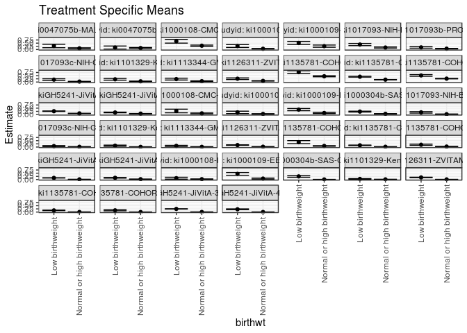

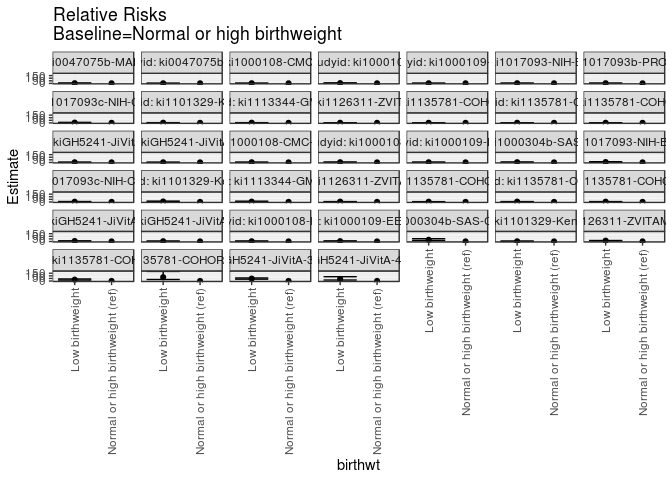

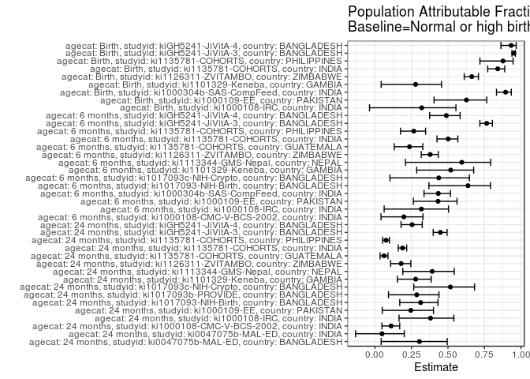

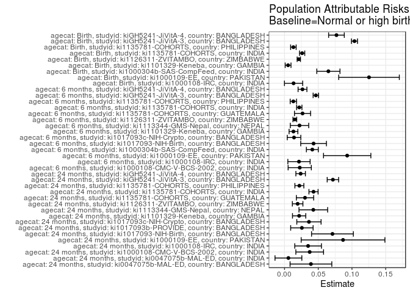

## Results Table

### Parameter: TSM

| agecat | studyid | country | intervention_level | baseline_level | estimate | ci_lower | ci_upper |
| --- | --- | --- | --- | --- | --- | --- | --- |
| Birth | ki1000108-IRC | INDIA | Normal or high birthweight | NA | 0.0283912 | 0.0100839 | 0.0466984 |
| Birth | ki1000108-IRC | INDIA | Low birthweight | NA | 0.1060606 | 0.0316774 | 0.1804438 |
| Birth | ki1000109-EE | PAKISTAN | Normal or high birthweight | NA | 0.0747301 | 0.0336318 | 0.1158285 |
| Birth | ki1000109-EE | PAKISTAN | Low birthweight | NA | 0.4456702 | 0.3365148 | 0.5548256 |
| Birth | ki1000304b-SAS-CompFeed | INDIA | Normal or high birthweight | NA | 0.0076586 | 0.0028611 | 0.0124562 |
| Birth | ki1000304b-SAS-CompFeed | INDIA | Low birthweight | NA | 0.2485207 | 0.1798026 | 0.3172388 |
| Birth | ki1101329-Keneba | GAMBIA | Normal or high birthweight | NA | 0.0136870 | 0.0073885 | 0.0199855 |
| Birth | ki1101329-Keneba | GAMBIA | Low birthweight | NA | 0.0466760 | 0.0192278 | 0.0741242 |
| Birth | ki1126311-ZVITAMBO | ZIMBABWE | Normal or high birthweight | NA | 0.0107339 | 0.0088857 | 0.0125821 |
| Birth | ki1126311-ZVITAMBO | ZIMBABWE | Low birthweight | NA | 0.1662450 | 0.1493296 | 0.1831604 |
| Birth | ki1135781-COHORTS | INDIA | Normal or high birthweight | NA | 0.0049403 | 0.0030445 | 0.0068362 |
| Birth | ki1135781-COHORTS | INDIA | Low birthweight | NA | 0.1308298 | 0.1127973 | 0.1488623 |
| Birth | ki1135781-COHORTS | PHILIPPINES | Normal or high birthweight | NA | 0.0018457 | 0.0002291 | 0.0034623 |
| Birth | ki1135781-COHORTS | PHILIPPINES | Low birthweight | NA | 0.1355932 | 0.0965193 | 0.1746672 |
| Birth | kiGH5241-JiVitA-3 | BANGLADESH | Normal or high birthweight | NA | 0.0053279 | 0.0040228 | 0.0066331 |
| Birth | kiGH5241-JiVitA-3 | BANGLADESH | Low birthweight | NA | 0.2452322 | 0.2358361 | 0.2546282 |
| Birth | kiGH5241-JiVitA-4 | BANGLADESH | Normal or high birthweight | NA | 0.0055389 | 0.0014975 | 0.0095803 |
| Birth | kiGH5241-JiVitA-4 | BANGLADESH | Low birthweight | NA | 0.2179077 | 0.1884773 | 0.2473382 |
| 6 months | ki1000108-CMC-V-BCS-2002 | INDIA | Normal or high birthweight | NA | 0.0912821 | 0.0599466 | 0.1226176 |
| 6 months | ki1000108-CMC-V-BCS-2002 | INDIA | Low birthweight | NA | 0.2784112 | 0.1368019 | 0.4200205 |
| 6 months | ki1000108-IRC | INDIA | Normal or high birthweight | NA | 0.0459078 | 0.0236223 | 0.0681933 |
| 6 months | ki1000108-IRC | INDIA | Low birthweight | NA | 0.1689423 | 0.0754325 | 0.2624522 |
| 6 months | ki1000109-EE | PAKISTAN | Normal or high birthweight | NA | 0.1221541 | 0.0807419 | 0.1635664 |
| 6 months | ki1000109-EE | PAKISTAN | Low birthweight | NA | 0.3882808 | 0.3027286 | 0.4738330 |
| 6 months | ki1000304b-SAS-CompFeed | INDIA | Normal or high birthweight | NA | 0.0538012 | 0.0376379 | 0.0699645 |
| 6 months | ki1000304b-SAS-CompFeed | INDIA | Low birthweight | NA | 0.2302899 | 0.1959868 | 0.2645930 |
| 6 months | ki1017093-NIH-Birth | BANGLADESH | Normal or high birthweight | NA | 0.0245232 | 0.0086840 | 0.0403623 |
| 6 months | ki1017093-NIH-Birth | BANGLADESH | Low birthweight | NA | 0.1721854 | 0.1119095 | 0.2324614 |
| 6 months | ki1017093c-NIH-Crypto | BANGLADESH | Normal or high birthweight | NA | 0.0181052 | 0.0068103 | 0.0294002 |
| 6 months | ki1017093c-NIH-Crypto | BANGLADESH | Low birthweight | NA | 0.0719378 | 0.0313203 | 0.1125553 |
| 6 months | ki1101329-Keneba | GAMBIA | Normal or high birthweight | NA | 0.0122603 | 0.0058712 | 0.0186493 |
| 6 months | ki1101329-Keneba | GAMBIA | Low birthweight | NA | 0.1056968 | 0.0624802 | 0.1489133 |
| 6 months | ki1113344-GMS-Nepal | NEPAL | Normal or high birthweight | NA | 0.0151134 | 0.0031014 | 0.0271253 |
| 6 months | ki1113344-GMS-Nepal | NEPAL | Low birthweight | NA | 0.0903614 | 0.0467092 | 0.1340136 |
| 6 months | ki1126311-ZVITAMBO | ZIMBABWE | Normal or high birthweight | NA | 0.0251336 | 0.0215990 | 0.0286681 |
| 6 months | ki1126311-ZVITAMBO | ZIMBABWE | Low birthweight | NA | 0.1530839 | 0.1320301 | 0.1741377 |
| 6 months | ki1135781-COHORTS | GUATEMALA | Normal or high birthweight | NA | 0.0861502 | 0.0654041 | 0.1068964 |
| 6 months | ki1135781-COHORTS | GUATEMALA | Low birthweight | NA | 0.3833215 | 0.2627715 | 0.5038715 |
| 6 months | ki1135781-COHORTS | INDIA | Normal or high birthweight | NA | 0.0217416 | 0.0176879 | 0.0257953 |
| 6 months | ki1135781-COHORTS | INDIA | Low birthweight | NA | 0.1357685 | 0.1169892 | 0.1545477 |
| 6 months | ki1135781-COHORTS | PHILIPPINES | Normal or high birthweight | NA | 0.0360694 | 0.0286267 | 0.0435120 |
| 6 months | ki1135781-COHORTS | PHILIPPINES | Low birthweight | NA | 0.1812133 | 0.1329372 | 0.2294894 |
| 6 months | kiGH5241-JiVitA-3 | BANGLADESH | Normal or high birthweight | NA | 0.0142366 | 0.0113781 | 0.0170951 |
| 6 months | kiGH5241-JiVitA-3 | BANGLADESH | Low birthweight | NA | 0.1288148 | 0.1194402 | 0.1381894 |
| 6 months | kiGH5241-JiVitA-4 | BANGLADESH | Normal or high birthweight | NA | 0.0278101 | 0.0202536 | 0.0353665 |
| 6 months | kiGH5241-JiVitA-4 | BANGLADESH | Low birthweight | NA | 0.1356807 | 0.1112568 | 0.1601047 |
| 24 months | ki0047075b-MAL-ED | BANGLADESH | Normal or high birthweight | NA | 0.0894093 | 0.0454434 | 0.1333751 |
| 24 months | ki0047075b-MAL-ED | BANGLADESH | Low birthweight | NA | 0.2794017 | 0.1425401 | 0.4162633 |
| 24 months | ki0047075b-MAL-ED | INDIA | Normal or high birthweight | NA | 0.1135135 | 0.0676972 | 0.1593299 |
| 24 months | ki0047075b-MAL-ED | INDIA | Low birthweight | NA | 0.1515152 | 0.0289013 | 0.2741290 |
| 24 months | ki1000108-CMC-V-BCS-2002 | INDIA | Normal or high birthweight | NA | 0.2996104 | 0.2499411 | 0.3492798 |
| 24 months | ki1000108-CMC-V-BCS-2002 | INDIA | Low birthweight | NA | 0.6485481 | 0.5026763 | 0.7944199 |
| 24 months | ki1000108-IRC | INDIA | Normal or high birthweight | NA | 0.0568730 | 0.0320777 | 0.0816684 |
| 24 months | ki1000108-IRC | INDIA | Low birthweight | NA | 0.2733797 | 0.1617215 | 0.3850379 |
| 24 months | ki1000109-EE | PAKISTAN | Normal or high birthweight | NA | 0.2665417 | 0.1797836 | 0.3532997 |
| 24 months | ki1000109-EE | PAKISTAN | Low birthweight | NA | 0.5169119 | 0.3957165 | 0.6381073 |
| 24 months | ki1017093-NIH-Birth | BANGLADESH | Normal or high birthweight | NA | 0.1559849 | 0.1135161 | 0.1984536 |
| 24 months | ki1017093-NIH-Birth | BANGLADESH | Low birthweight | NA | 0.3911154 | 0.3059634 | 0.4762674 |
| 24 months | ki1017093b-PROVIDE | BANGLADESH | Normal or high birthweight | NA | 0.0642246 | 0.0412049 | 0.0872443 |
| 24 months | ki1017093b-PROVIDE | BANGLADESH | Low birthweight | NA | 0.1677463 | 0.1041178 | 0.2313748 |
| 24 months | ki1017093c-NIH-Crypto | BANGLADESH | Normal or high birthweight | NA | 0.0338428 | 0.0159375 | 0.0517482 |
| 24 months | ki1017093c-NIH-Crypto | BANGLADESH | Low birthweight | NA | 0.1869794 | 0.1181962 | 0.2557625 |
| 24 months | ki1101329-Keneba | GAMBIA | Normal or high birthweight | NA | 0.0560084 | 0.0409948 | 0.0710221 |
| 24 months | ki1101329-Keneba | GAMBIA | Low birthweight | NA | 0.2123058 | 0.1460005 | 0.2786112 |
| 24 months | ki1113344-GMS-Nepal | NEPAL | Normal or high birthweight | NA | 0.0661596 | 0.0400902 | 0.0922290 |
| 24 months | ki1113344-GMS-Nepal | NEPAL | Low birthweight | NA | 0.2290361 | 0.1569241 | 0.3011481 |
| 24 months | ki1126311-ZVITAMBO | ZIMBABWE | Normal or high birthweight | NA | 0.0888299 | 0.0741075 | 0.1035522 |
| 24 months | ki1126311-ZVITAMBO | ZIMBABWE | Low birthweight | NA | 0.2594662 | 0.1976988 | 0.3212336 |
| 24 months | ki1135781-COHORTS | GUATEMALA | Normal or high birthweight | NA | 0.4527212 | 0.4124632 | 0.4929791 |
| 24 months | ki1135781-COHORTS | GUATEMALA | Low birthweight | NA | 0.7776378 | 0.6688714 | 0.8864041 |
| 24 months | ki1135781-COHORTS | INDIA | Normal or high birthweight | NA | 0.1844764 | 0.1723884 | 0.1965643 |
| 24 months | ki1135781-COHORTS | INDIA | Low birthweight | NA | 0.4173004 | 0.3854833 | 0.4491174 |
| 24 months | ki1135781-COHORTS | PHILIPPINES | Normal or high birthweight | NA | 0.2660371 | 0.2475413 | 0.2845330 |
| 24 months | ki1135781-COHORTS | PHILIPPINES | Low birthweight | NA | 0.5185328 | 0.4517669 | 0.5852988 |
| 24 months | kiGH5241-JiVitA-3 | BANGLADESH | Normal or high birthweight | NA | 0.0882543 | 0.0786609 | 0.0978477 |
| 24 months | kiGH5241-JiVitA-3 | BANGLADESH | Low birthweight | NA | 0.2617646 | 0.2441468 | 0.2793825 |
| 24 months | kiGH5241-JiVitA-4 | BANGLADESH | Normal or high birthweight | NA | 0.0698752 | 0.0592045 | 0.0805459 |
| 24 months | kiGH5241-JiVitA-4 | BANGLADESH | Low birthweight | NA | 0.1613836 | 0.1367491 | 0.1860181 |

### Parameter: E(Y)

| agecat | studyid | country | intervention_level | baseline_level | estimate | ci_lower | ci_upper |
| --- | --- | --- | --- | --- | --- | --- | --- |
| Birth | ki1000108-IRC | INDIA | NA | NA | 0.0417755 | 0.0217118 | 0.0618391 |
| Birth | ki1000109-EE | PAKISTAN | NA | NA | 0.2000000 | 0.1492882 | 0.2507118 |
| Birth | ki1000304b-SAS-CompFeed | INDIA | NA | NA | 0.0726837 | 0.0523147 | 0.0930527 |
| Birth | ki1101329-Keneba | GAMBIA | NA | NA | 0.0189666 | 0.0121272 | 0.0258061 |
| Birth | ki1126311-ZVITAMBO | ZIMBABWE | NA | NA | 0.0318872 | 0.0289588 | 0.0348156 |
| Birth | ki1135781-COHORTS | INDIA | NA | NA | 0.0310334 | 0.0268616 | 0.0352053 |
| Birth | ki1135781-COHORTS | PHILIPPINES | NA | NA | 0.0149800 | 0.0106354 | 0.0193246 |
| Birth | kiGH5241-JiVitA-3 | BANGLADESH | NA | NA | 0.1090229 | 0.1044694 | 0.1135764 |
| Birth | kiGH5241-JiVitA-4 | BANGLADESH | NA | NA | 0.0825363 | 0.0708486 | 0.0942240 |
| 6 months | ki1000108-CMC-V-BCS-2002 | INDIA | NA | NA | 0.1138211 | 0.0813725 | 0.1462698 |
| 6 months | ki1000108-IRC | INDIA | NA | NA | 0.0673317 | 0.0427738 | 0.0918896 |
| 6 months | ki1000109-EE | PAKISTAN | NA | NA | 0.2150538 | 0.1732462 | 0.2568613 |
| 6 months | ki1000304b-SAS-CompFeed | INDIA | NA | NA | 0.0950226 | 0.0765320 | 0.1135132 |
| 6 months | ki1017093-NIH-Birth | BANGLADESH | NA | NA | 0.0675676 | 0.0459314 | 0.0892038 |
| 6 months | ki1017093c-NIH-Crypto | BANGLADESH | NA | NA | 0.0321678 | 0.0192256 | 0.0451101 |
| 6 months | ki1101329-Keneba | GAMBIA | NA | NA | 0.0254873 | 0.0170269 | 0.0339476 |
| 6 months | ki1113344-GMS-Nepal | NEPAL | NA | NA | 0.0373002 | 0.0216334 | 0.0529670 |
| 6 months | ki1126311-ZVITAMBO | ZIMBABWE | NA | NA | 0.0404122 | 0.0362587 | 0.0445657 |
| 6 months | ki1135781-COHORTS | GUATEMALA | NA | NA | 0.1128405 | 0.0904926 | 0.1351883 |
| 6 months | ki1135781-COHORTS | INDIA | NA | NA | 0.0436033 | 0.0385446 | 0.0486620 |
| 6 months | ki1135781-COHORTS | PHILIPPINES | NA | NA | 0.0491373 | 0.0409307 | 0.0573439 |
| 6 months | kiGH5241-JiVitA-3 | BANGLADESH | NA | NA | 0.0606511 | 0.0563622 | 0.0649400 |
| 6 months | kiGH5241-JiVitA-4 | BANGLADESH | NA | NA | 0.0544420 | 0.0459722 | 0.0629117 |
| 24 months | ki0047075b-MAL-ED | BANGLADESH | NA | NA | 0.1285714 | 0.0831916 | 0.1739513 |
| 24 months | ki0047075b-MAL-ED | INDIA | NA | NA | 0.1192661 | 0.0761440 | 0.1623881 |
| 24 months | ki1000108-CMC-V-BCS-2002 | INDIA | NA | NA | 0.3369272 | 0.2887662 | 0.3850883 |
| 24 months | ki1000108-IRC | INDIA | NA | NA | 0.0918114 | 0.0635840 | 0.1200388 |
| 24 months | ki1000109-EE | PAKISTAN | NA | NA | 0.3532934 | 0.2805798 | 0.4260070 |
| 24 months | ki1017093-NIH-Birth | BANGLADESH | NA | NA | 0.2270531 | 0.1866503 | 0.2674560 |
| 24 months | ki1017093b-PROVIDE | BANGLADESH | NA | NA | 0.0899654 | 0.0666186 | 0.1133122 |
| 24 months | ki1017093c-NIH-Crypto | BANGLADESH | NA | NA | 0.0700389 | 0.0479542 | 0.0921236 |
| 24 months | ki1101329-Keneba | GAMBIA | NA | NA | 0.0776515 | 0.0615026 | 0.0938005 |
| 24 months | ki1113344-GMS-Nepal | NEPAL | NA | NA | 0.1088296 | 0.0811421 | 0.1365171 |
| 24 months | ki1126311-ZVITAMBO | ZIMBABWE | NA | NA | 0.1082569 | 0.0931919 | 0.1233219 |
| 24 months | ki1135781-COHORTS | GUATEMALA | NA | NA | 0.4830769 | 0.4446313 | 0.5215225 |
| 24 months | ki1135781-COHORTS | INDIA | NA | NA | 0.2274599 | 0.2156709 | 0.2392489 |
| 24 months | ki1135781-COHORTS | PHILIPPINES | NA | NA | 0.2880299 | 0.2699315 | 0.3061283 |
| 24 months | kiGH5241-JiVitA-3 | BANGLADESH | NA | NA | 0.1599836 | 0.1502803 | 0.1696868 |
| 24 months | kiGH5241-JiVitA-4 | BANGLADESH | NA | NA | 0.0937656 | 0.0834379 | 0.1040932 |

### Parameter: RR

| agecat | studyid | country | intervention_level | baseline_level | estimate | ci_lower | ci_upper |
| --- | --- | --- | --- | --- | --- | --- | --- |
| Birth | ki1000108-IRC | INDIA | Normal or high birthweight | Normal or high birthweight | 1.000000 | 1.0000000 | 1.000000 |
| Birth | ki1000108-IRC | INDIA | Low birthweight | Normal or high birthweight | 3.735690 | 1.4408347 | 9.685623 |
| Birth | ki1000109-EE | PAKISTAN | Normal or high birthweight | Normal or high birthweight | 1.000000 | 1.0000000 | 1.000000 |
| Birth | ki1000109-EE | PAKISTAN | Low birthweight | Normal or high birthweight | 5.963729 | 3.2612598 | 10.905621 |
| Birth | ki1000304b-SAS-CompFeed | INDIA | Normal or high birthweight | Normal or high birthweight | 1.000000 | 1.0000000 | 1.000000 |
| Birth | ki1000304b-SAS-CompFeed | INDIA | Low birthweight | Normal or high birthweight | 32.449704 | 19.4675935 | 54.089032 |
| Birth | ki1101329-Keneba | GAMBIA | Normal or high birthweight | Normal or high birthweight | 1.000000 | 1.0000000 | 1.000000 |
| Birth | ki1101329-Keneba | GAMBIA | Low birthweight | Normal or high birthweight | 3.410251 | 1.6157701 | 7.197691 |
| Birth | ki1126311-ZVITAMBO | ZIMBABWE | Normal or high birthweight | Normal or high birthweight | 1.000000 | 1.0000000 | 1.000000 |
| Birth | ki1126311-ZVITAMBO | ZIMBABWE | Low birthweight | Normal or high birthweight | 15.487860 | 12.6797126 | 18.917921 |
| Birth | ki1135781-COHORTS | INDIA | Normal or high birthweight | Normal or high birthweight | 1.000000 | 1.0000000 | 1.000000 |
| Birth | ki1135781-COHORTS | INDIA | Low birthweight | Normal or high birthweight | 26.481953 | 17.6150809 | 39.812128 |
| Birth | ki1135781-COHORTS | PHILIPPINES | Normal or high birthweight | Normal or high birthweight | 1.000000 | 1.0000000 | 1.000000 |
| Birth | ki1135781-COHORTS | PHILIPPINES | Low birthweight | Normal or high birthweight | 73.464407 | 29.2170860 | 184.721332 |
| Birth | kiGH5241-JiVitA-3 | BANGLADESH | Normal or high birthweight | Normal or high birthweight | 1.000000 | 1.0000000 | 1.000000 |
| Birth | kiGH5241-JiVitA-3 | BANGLADESH | Low birthweight | Normal or high birthweight | 46.027593 | 36.0014879 | 58.845881 |
| Birth | kiGH5241-JiVitA-4 | BANGLADESH | Normal or high birthweight | Normal or high birthweight | 1.000000 | 1.0000000 | 1.000000 |
| Birth | kiGH5241-JiVitA-4 | BANGLADESH | Low birthweight | Normal or high birthweight | 39.341407 | 18.6380488 | 83.042294 |
| 6 months | ki1000108-CMC-V-BCS-2002 | INDIA | Normal or high birthweight | Normal or high birthweight | 1.000000 | 1.0000000 | 1.000000 |
| 6 months | ki1000108-CMC-V-BCS-2002 | INDIA | Low birthweight | Normal or high birthweight | 3.050009 | 1.6515088 | 5.632762 |
| 6 months | ki1000108-IRC | INDIA | Normal or high birthweight | Normal or high birthweight | 1.000000 | 1.0000000 | 1.000000 |
| 6 months | ki1000108-IRC | INDIA | Low birthweight | Normal or high birthweight | 3.680036 | 1.7635455 | 7.679227 |
| 6 months | ki1000109-EE | PAKISTAN | Normal or high birthweight | Normal or high birthweight | 1.000000 | 1.0000000 | 1.000000 |
| 6 months | ki1000109-EE | PAKISTAN | Low birthweight | Normal or high birthweight | 3.178613 | 2.1239355 | 4.757010 |
| 6 months | ki1000304b-SAS-CompFeed | INDIA | Normal or high birthweight | Normal or high birthweight | 1.000000 | 1.0000000 | 1.000000 |
| 6 months | ki1000304b-SAS-CompFeed | INDIA | Low birthweight | Normal or high birthweight | 4.280384 | 3.1517671 | 5.813148 |
| 6 months | ki1017093-NIH-Birth | BANGLADESH | Normal or high birthweight | Normal or high birthweight | 1.000000 | 1.0000000 | 1.000000 |
| 6 months | ki1017093-NIH-Birth | BANGLADESH | Low birthweight | Normal or high birthweight | 7.021339 | 3.3679464 | 14.637764 |
| 6 months | ki1017093c-NIH-Crypto | BANGLADESH | Normal or high birthweight | Normal or high birthweight | 1.000000 | 1.0000000 | 1.000000 |
| 6 months | ki1017093c-NIH-Crypto | BANGLADESH | Low birthweight | Normal or high birthweight | 3.973318 | 1.7138642 | 9.211498 |
| 6 months | ki1101329-Keneba | GAMBIA | Normal or high birthweight | Normal or high birthweight | 1.000000 | 1.0000000 | 1.000000 |
| 6 months | ki1101329-Keneba | GAMBIA | Low birthweight | Normal or high birthweight | 8.621085 | 4.4582784 | 16.670807 |
| 6 months | ki1113344-GMS-Nepal | NEPAL | Normal or high birthweight | Normal or high birthweight | 1.000000 | 1.0000000 | 1.000000 |
| 6 months | ki1113344-GMS-Nepal | NEPAL | Low birthweight | Normal or high birthweight | 5.978916 | 2.3588012 | 15.154915 |
| 6 months | ki1126311-ZVITAMBO | ZIMBABWE | Normal or high birthweight | Normal or high birthweight | 1.000000 | 1.0000000 | 1.000000 |
| 6 months | ki1126311-ZVITAMBO | ZIMBABWE | Low birthweight | Normal or high birthweight | 6.090813 | 5.0042581 | 7.413288 |
| 6 months | ki1135781-COHORTS | GUATEMALA | Normal or high birthweight | Normal or high birthweight | 1.000000 | 1.0000000 | 1.000000 |
| 6 months | ki1135781-COHORTS | GUATEMALA | Low birthweight | Normal or high birthweight | 4.449454 | 2.9927946 | 6.615101 |
| 6 months | ki1135781-COHORTS | INDIA | Normal or high birthweight | Normal or high birthweight | 1.000000 | 1.0000000 | 1.000000 |
| 6 months | ki1135781-COHORTS | INDIA | Low birthweight | Normal or high birthweight | 6.244643 | 4.9523912 | 7.874088 |
| 6 months | ki1135781-COHORTS | PHILIPPINES | Normal or high birthweight | Normal or high birthweight | 1.000000 | 1.0000000 | 1.000000 |
| 6 months | ki1135781-COHORTS | PHILIPPINES | Low birthweight | Normal or high birthweight | 5.024021 | 3.5885521 | 7.033696 |
| 6 months | kiGH5241-JiVitA-3 | BANGLADESH | Normal or high birthweight | Normal or high birthweight | 1.000000 | 1.0000000 | 1.000000 |
| 6 months | kiGH5241-JiVitA-3 | BANGLADESH | Low birthweight | Normal or high birthweight | 9.048117 | 7.3261560 | 11.174814 |
| 6 months | kiGH5241-JiVitA-4 | BANGLADESH | Normal or high birthweight | Normal or high birthweight | 1.000000 | 1.0000000 | 1.000000 |
| 6 months | kiGH5241-JiVitA-4 | BANGLADESH | Low birthweight | Normal or high birthweight | 4.878835 | 3.5264297 | 6.749895 |
| 24 months | ki0047075b-MAL-ED | BANGLADESH | Normal or high birthweight | Normal or high birthweight | 1.000000 | 1.0000000 | 1.000000 |
| 24 months | ki0047075b-MAL-ED | BANGLADESH | Low birthweight | Normal or high birthweight | 3.124976 | 1.5657754 | 6.236829 |
| 24 months | ki0047075b-MAL-ED | INDIA | Normal or high birthweight | Normal or high birthweight | 1.000000 | 1.0000000 | 1.000000 |
| 24 months | ki0047075b-MAL-ED | INDIA | Low birthweight | Normal or high birthweight | 1.334776 | 0.5403395 | 3.297238 |
| 24 months | ki1000108-CMC-V-BCS-2002 | INDIA | Normal or high birthweight | Normal or high birthweight | 1.000000 | 1.0000000 | 1.000000 |
| 24 months | ki1000108-CMC-V-BCS-2002 | INDIA | Low birthweight | Normal or high birthweight | 2.164638 | 1.6382597 | 2.860143 |
| 24 months | ki1000108-IRC | INDIA | Normal or high birthweight | Normal or high birthweight | 1.000000 | 1.0000000 | 1.000000 |
| 24 months | ki1000108-IRC | INDIA | Low birthweight | Normal or high birthweight | 4.806843 | 2.6393605 | 8.754294 |
| 24 months | ki1000109-EE | PAKISTAN | Normal or high birthweight | Normal or high birthweight | 1.000000 | 1.0000000 | 1.000000 |
| 24 months | ki1000109-EE | PAKISTAN | Low birthweight | Normal or high birthweight | 1.939329 | 1.2968714 | 2.900053 |
| 24 months | ki1017093-NIH-Birth | BANGLADESH | Normal or high birthweight | Normal or high birthweight | 1.000000 | 1.0000000 | 1.000000 |
| 24 months | ki1017093-NIH-Birth | BANGLADESH | Low birthweight | Normal or high birthweight | 2.507393 | 1.7705073 | 3.550972 |
| 24 months | ki1017093b-PROVIDE | BANGLADESH | Normal or high birthweight | Normal or high birthweight | 1.000000 | 1.0000000 | 1.000000 |
| 24 months | ki1017093b-PROVIDE | BANGLADESH | Low birthweight | Normal or high birthweight | 2.611871 | 1.5507881 | 4.398970 |
| 24 months | ki1017093c-NIH-Crypto | BANGLADESH | Normal or high birthweight | Normal or high birthweight | 1.000000 | 1.0000000 | 1.000000 |
| 24 months | ki1017093c-NIH-Crypto | BANGLADESH | Low birthweight | Normal or high birthweight | 5.524932 | 2.8986632 | 10.530672 |
| 24 months | ki1101329-Keneba | GAMBIA | Normal or high birthweight | Normal or high birthweight | 1.000000 | 1.0000000 | 1.000000 |
| 24 months | ki1101329-Keneba | GAMBIA | Low birthweight | Normal or high birthweight | 3.790604 | 2.5164072 | 5.709998 |
| 24 months | ki1113344-GMS-Nepal | NEPAL | Normal or high birthweight | Normal or high birthweight | 1.000000 | 1.0000000 | 1.000000 |
| 24 months | ki1113344-GMS-Nepal | NEPAL | Low birthweight | Normal or high birthweight | 3.461873 | 2.0946682 | 5.721463 |
| 24 months | ki1126311-ZVITAMBO | ZIMBABWE | Normal or high birthweight | Normal or high birthweight | 1.000000 | 1.0000000 | 1.000000 |
| 24 months | ki1126311-ZVITAMBO | ZIMBABWE | Low birthweight | Normal or high birthweight | 2.920933 | 2.1867157 | 3.901674 |
| 24 months | ki1135781-COHORTS | GUATEMALA | Normal or high birthweight | Normal or high birthweight | 1.000000 | 1.0000000 | 1.000000 |
| 24 months | ki1135781-COHORTS | GUATEMALA | Low birthweight | Normal or high birthweight | 1.717697 | 1.4554736 | 2.027163 |
| 24 months | ki1135781-COHORTS | INDIA | Normal or high birthweight | Normal or high birthweight | 1.000000 | 1.0000000 | 1.000000 |
| 24 months | ki1135781-COHORTS | INDIA | Low birthweight | Normal or high birthweight | 2.262080 | 2.0471695 | 2.499552 |
| 24 months | ki1135781-COHORTS | PHILIPPINES | Normal or high birthweight | Normal or high birthweight | 1.000000 | 1.0000000 | 1.000000 |
| 24 months | ki1135781-COHORTS | PHILIPPINES | Low birthweight | Normal or high birthweight | 1.949099 | 1.6852477 | 2.254261 |
| 24 months | kiGH5241-JiVitA-3 | BANGLADESH | Normal or high birthweight | Normal or high birthweight | 1.000000 | 1.0000000 | 1.000000 |
| 24 months | kiGH5241-JiVitA-3 | BANGLADESH | Low birthweight | Normal or high birthweight | 2.966027 | 2.6151448 | 3.363988 |
| 24 months | kiGH5241-JiVitA-4 | BANGLADESH | Normal or high birthweight | Normal or high birthweight | 1.000000 | 1.0000000 | 1.000000 |
| 24 months | kiGH5241-JiVitA-4 | BANGLADESH | Low birthweight | Normal or high birthweight | 2.309598 | 1.8618048 | 2.865092 |

### Parameter: PAR

| agecat | studyid | country | intervention_level | baseline_level | estimate | ci_lower | ci_upper |
| --- | --- | --- | --- | --- | --- | --- | --- |
| Birth | ki1000108-IRC | INDIA | Normal or high birthweight | NA | 0.0133843 | -0.0001400 | 0.0269086 |
| Birth | ki1000109-EE | PAKISTAN | Normal or high birthweight | NA | 0.1252699 | 0.0803172 | 0.1702225 |
| Birth | ki1000304b-SAS-CompFeed | INDIA | Normal or high birthweight | NA | 0.0650251 | 0.0478410 | 0.0822091 |
| Birth | ki1101329-Keneba | GAMBIA | Normal or high birthweight | NA | 0.0052797 | 0.0009831 | 0.0095762 |
| Birth | ki1126311-ZVITAMBO | ZIMBABWE | Normal or high birthweight | NA | 0.0211533 | 0.0186886 | 0.0236180 |
| Birth | ki1135781-COHORTS | INDIA | Normal or high birthweight | NA | 0.0260931 | 0.0221810 | 0.0300052 |
| Birth | ki1135781-COHORTS | PHILIPPINES | Normal or high birthweight | NA | 0.0131343 | 0.0090385 | 0.0172301 |
| Birth | kiGH5241-JiVitA-3 | BANGLADESH | Normal or high birthweight | NA | 0.1036950 | 0.0992011 | 0.1081888 |
| Birth | kiGH5241-JiVitA-4 | BANGLADESH | Normal or high birthweight | NA | 0.0769974 | 0.0653713 | 0.0886236 |
| 6 months | ki1000108-CMC-V-BCS-2002 | INDIA | Normal or high birthweight | NA | 0.0225390 | 0.0053267 | 0.0397514 |
| 6 months | ki1000108-IRC | INDIA | Normal or high birthweight | NA | 0.0214239 | 0.0049143 | 0.0379334 |
| 6 months | ki1000109-EE | PAKISTAN | Normal or high birthweight | NA | 0.0928996 | 0.0577941 | 0.1280052 |
| 6 months | ki1000304b-SAS-CompFeed | INDIA | Normal or high birthweight | NA | 0.0412214 | 0.0324011 | 0.0500417 |
| 6 months | ki1017093-NIH-Birth | BANGLADESH | Normal or high birthweight | NA | 0.0430444 | 0.0239784 | 0.0621104 |
| 6 months | ki1017093c-NIH-Crypto | BANGLADESH | Normal or high birthweight | NA | 0.0140626 | 0.0040184 | 0.0241068 |
| 6 months | ki1101329-Keneba | GAMBIA | Normal or high birthweight | NA | 0.0132270 | 0.0067507 | 0.0197033 |
| 6 months | ki1113344-GMS-Nepal | NEPAL | Normal or high birthweight | NA | 0.0221868 | 0.0085395 | 0.0358341 |
| 6 months | ki1126311-ZVITAMBO | ZIMBABWE | Normal or high birthweight | NA | 0.0152786 | 0.0124817 | 0.0180756 |
| 6 months | ki1135781-COHORTS | GUATEMALA | Normal or high birthweight | NA | 0.0266902 | 0.0147538 | 0.0386267 |
| 6 months | ki1135781-COHORTS | INDIA | Normal or high birthweight | NA | 0.0218617 | 0.0179054 | 0.0258179 |
| 6 months | ki1135781-COHORTS | PHILIPPINES | Normal or high birthweight | NA | 0.0130679 | 0.0083876 | 0.0177482 |
| 6 months | kiGH5241-JiVitA-3 | BANGLADESH | Normal or high birthweight | NA | 0.0464145 | 0.0424158 | 0.0504131 |
| 6 months | kiGH5241-JiVitA-4 | BANGLADESH | Normal or high birthweight | NA | 0.0266319 | 0.0200928 | 0.0331710 |
| 24 months | ki0047075b-MAL-ED | BANGLADESH | Normal or high birthweight | NA | 0.0391622 | 0.0082237 | 0.0701006 |
| 24 months | ki0047075b-MAL-ED | INDIA | Normal or high birthweight | NA | 0.0057525 | -0.0141444 | 0.0256495 |
| 24 months | ki1000108-CMC-V-BCS-2002 | INDIA | Normal or high birthweight | NA | 0.0373168 | 0.0167679 | 0.0578657 |
| 24 months | ki1000108-IRC | INDIA | Normal or high birthweight | NA | 0.0349384 | 0.0151483 | 0.0547285 |
| 24 months | ki1000109-EE | PAKISTAN | Normal or high birthweight | NA | 0.0867518 | 0.0246616 | 0.1488419 |
| 24 months | ki1017093-NIH-Birth | BANGLADESH | Normal or high birthweight | NA | 0.0710683 | 0.0400746 | 0.1020620 |
| 24 months | ki1017093b-PROVIDE | BANGLADESH | Normal or high birthweight | NA | 0.0257408 | 0.0091216 | 0.0423600 |
| 24 months | ki1017093c-NIH-Crypto | BANGLADESH | Normal or high birthweight | NA | 0.0361961 | 0.0182059 | 0.0541863 |
| 24 months | ki1101329-Keneba | GAMBIA | Normal or high birthweight | NA | 0.0216431 | 0.0118153 | 0.0314709 |
| 24 months | ki1113344-GMS-Nepal | NEPAL | Normal or high birthweight | NA | 0.0426700 | 0.0214352 | 0.0639048 |
| 24 months | ki1126311-ZVITAMBO | ZIMBABWE | Normal or high birthweight | NA | 0.0194270 | 0.0116019 | 0.0272521 |
| 24 months | ki1135781-COHORTS | GUATEMALA | Normal or high birthweight | NA | 0.0303558 | 0.0175107 | 0.0432009 |
| 24 months | ki1135781-COHORTS | INDIA | Normal or high birthweight | NA | 0.0429835 | 0.0362158 | 0.0497512 |
| 24 months | ki1135781-COHORTS | PHILIPPINES | Normal or high birthweight | NA | 0.0219928 | 0.0153684 | 0.0286171 |
| 24 months | kiGH5241-JiVitA-3 | BANGLADESH | Normal or high birthweight | NA | 0.0717293 | 0.0632647 | 0.0801939 |
| 24 months | kiGH5241-JiVitA-4 | BANGLADESH | Normal or high birthweight | NA | 0.0238904 | 0.0168153 | 0.0309655 |

### Parameter: PAF

| agecat | studyid | country | intervention_level | baseline_level | estimate | ci_lower | ci_upper |
| --- | --- | --- | --- | --- | --- | --- | --- |
| Birth | ki1000108-IRC | INDIA | Normal or high birthweight | NA | 0.3203864 | -0.0371590 | 0.5546733 |
| Birth | ki1000109-EE | PAKISTAN | Normal or high birthweight | NA | 0.6263494 | 0.4047301 | 0.7654597 |
| Birth | ki1000304b-SAS-CompFeed | INDIA | Normal or high birthweight | NA | 0.8946305 | 0.8325207 | 0.9337069 |
| Birth | ki1101329-Keneba | GAMBIA | Normal or high birthweight | NA | 0.2783664 | 0.0426370 | 0.4560527 |
| Birth | ki1126311-ZVITAMBO | ZIMBABWE | Normal or high birthweight | NA | 0.6633794 | 0.6111633 | 0.7085834 |
| Birth | ki1135781-COHORTS | INDIA | Normal or high birthweight | NA | 0.8408060 | 0.7722690 | 0.8887164 |
| Birth | ki1135781-COHORTS | PHILIPPINES | Normal or high birthweight | NA | 0.8767893 | 0.7188230 | 0.9460095 |
| Birth | kiGH5241-JiVitA-3 | BANGLADESH | Normal or high birthweight | NA | 0.9511301 | 0.9378371 | 0.9615805 |
| Birth | kiGH5241-JiVitA-4 | BANGLADESH | Normal or high birthweight | NA | 0.9328915 | 0.8625940 | 0.9672245 |
| 6 months | ki1000108-CMC-V-BCS-2002 | INDIA | Normal or high birthweight | NA | 0.1980216 | 0.0415109 | 0.3289759 |
| 6 months | ki1000108-IRC | INDIA | Normal or high birthweight | NA | 0.3181843 | 0.0629949 | 0.5038740 |
| 6 months | ki1000109-EE | PAKISTAN | Normal or high birthweight | NA | 0.4319832 | 0.2630107 | 0.5622147 |
| 6 months | ki1000304b-SAS-CompFeed | INDIA | Normal or high birthweight | NA | 0.4338062 | 0.3360666 | 0.5171573 |
| 6 months | ki1017093-NIH-Birth | BANGLADESH | Normal or high birthweight | NA | 0.6370572 | 0.3694075 | 0.7911052 |
| 6 months | ki1017093c-NIH-Crypto | BANGLADESH | Normal or high birthweight | NA | 0.4371637 | 0.1026010 | 0.6469968 |
| 6 months | ki1101329-Keneba | GAMBIA | Normal or high birthweight | NA | 0.5189650 | 0.2857253 | 0.6760425 |
| 6 months | ki1113344-GMS-Nepal | NEPAL | Normal or high birthweight | NA | 0.5948183 | 0.2092188 | 0.7923924 |
| 6 months | ki1126311-ZVITAMBO | ZIMBABWE | Normal or high birthweight | NA | 0.3780699 | 0.3170577 | 0.4336315 |
| 6 months | ki1135781-COHORTS | GUATEMALA | Normal or high birthweight | NA | 0.2365306 | 0.1328290 | 0.3278310 |
| 6 months | ki1135781-COHORTS | INDIA | Normal or high birthweight | NA | 0.5013769 | 0.4248102 | 0.5677513 |
| 6 months | ki1135781-COHORTS | PHILIPPINES | Normal or high birthweight | NA | 0.2659469 | 0.1752329 | 0.3466834 |
| 6 months | kiGH5241-JiVitA-3 | BANGLADESH | Normal or high birthweight | NA | 0.7652698 | 0.7184594 | 0.8042973 |
| 6 months | kiGH5241-JiVitA-4 | BANGLADESH | Normal or high birthweight | NA | 0.4891796 | 0.3742521 | 0.5829990 |
| 24 months | ki0047075b-MAL-ED | BANGLADESH | Normal or high birthweight | NA | 0.3045947 | 0.0424079 | 0.4949953 |
| 24 months | ki0047075b-MAL-ED | INDIA | Normal or high birthweight | NA | 0.0482328 | -0.1333022 | 0.2006891 |
| 24 months | ki1000108-CMC-V-BCS-2002 | INDIA | Normal or high birthweight | NA | 0.1107563 | 0.0477795 | 0.1695679 |
| 24 months | ki1000108-IRC | INDIA | Normal or high birthweight | NA | 0.3805451 | 0.1648436 | 0.5405360 |
| 24 months | ki1000109-EE | PAKISTAN | Normal or high birthweight | NA | 0.2455516 | 0.0498984 | 0.4009142 |
| 24 months | ki1017093-NIH-Birth | BANGLADESH | Normal or high birthweight | NA | 0.3130029 | 0.1696905 | 0.4315794 |
| 24 months | ki1017093b-PROVIDE | BANGLADESH | Normal or high birthweight | NA | 0.2861191 | 0.0925407 | 0.4384036 |
| 24 months | ki1017093c-NIH-Crypto | BANGLADESH | Normal or high birthweight | NA | 0.5167995 | 0.2659342 | 0.6819321 |
| 24 months | ki1101329-Keneba | GAMBIA | Normal or high birthweight | NA | 0.2787206 | 0.1537748 | 0.3852181 |
| 24 months | ki1113344-GMS-Nepal | NEPAL | Normal or high birthweight | NA | 0.3920808 | 0.1908565 | 0.5432630 |
| 24 months | ki1126311-ZVITAMBO | ZIMBABWE | Normal or high birthweight | NA | 0.1794528 | 0.1075195 | 0.2455883 |
| 24 months | ki1135781-COHORTS | GUATEMALA | Normal or high birthweight | NA | 0.0628384 | 0.0355024 | 0.0893996 |
| 24 months | ki1135781-COHORTS | INDIA | Normal or high birthweight | NA | 0.1889717 | 0.1594654 | 0.2174423 |
| 24 months | ki1135781-COHORTS | PHILIPPINES | Normal or high birthweight | NA | 0.0763559 | 0.0531573 | 0.0989861 |
| 24 months | kiGH5241-JiVitA-3 | BANGLADESH | Normal or high birthweight | NA | 0.4483540 | 0.3988598 | 0.4937731 |
| 24 months | kiGH5241-JiVitA-4 | BANGLADESH | Normal or high birthweight | NA | 0.2547885 | 0.1787748 | 0.3237662 |